# Click Analysis Spring 2017

This is an [R Markdown](http://rmarkdown.rstudio.com) for the clicks analysis of Spring 2017. We fit a linear regression model with the number of clicks as the predictor and novelty score / user requirement score as the outcome variable.

## Notes

> Significant tests show if a linear relationship exists but not the strength of the relationship. The coefficient of determination, R2, is a descriptive measure of the strength of the regression relationship, a measure on how well the regression line fits the data. In general the higher the value of R2, the better the model fits the data.b • R2 = 1: Perfect match between the line and the data points. • R2 = 0: There are no linear relationship between x and y. R2 is an effect size measure. Cohen (1988) defined some standards for interpreting R2 . • R2 = .01: Small effect • R2 = .06: Medium effect • R2 = .15: Large effect.

```r
scores_loc <- read.table("/Users/jialincheoh/Library/CloudStorage/Box-Box/NSF IronHacks App 2016 - 2019/05 Experiments 2017/01 Hack Spring 2017/01 Summary Spring 2017/02 Data/processed-data/overall_score_click_result.csv", header=TRUE, sep = ",")
scores_loc
```

| X | Student | Group | user.requirement.phase5 | infovis.phase5 | novelty.phase5 | total.phase5 | tech.phase5 | tech.phase4 | user.requirement.phase4 | infovis.phase4 | novelty.phase4 | total.phase4 | tech.phase3 | user.requirement.phase3 | infovis.phase3 | novelty.phase3 | total.phase3 | tech.phase2 | user.requirement.phase2 | infovis.phase2 | novelty.phase2 | total.phase2 | tech.phase1 | user.requirement.phase1 | infovis.phase1 | novelty.phase1 | total.phase1 | improve.ur.12 | improve.ur.23 | … |
| --- | --- | --- | --- | --- | --- | --- | --- | --- | --- | --- | --- | --- | --- | --- | --- | --- | --- | --- | --- | --- | --- | --- | --- | --- | --- | --- | --- | --- | --- | --- |
| 0 | fffeelipe | 0 | 20 | 29.17 | 50.00 | 199.17 | 100.0 | 100.0 | 20 | 29.17 | 43.75 | 192.92 | 75.0 | 60 | 37.50 | 0.00 | 172.50 | 75.0 | 60 | 37.50 | 0.00 | 172.50 | 50.0 | 20 | 29.17 | 0.00 | 99.17 | 40 | 0 | … |
| 1 | mnguzmanc | 0 | 60 | 75.00 | 67.50 | 290.00 | 87.5 | 87.5 | 20 | 37.50 | 100.00 | 245.00 | 100.0 | 20 | 41.67 | 75.00 | 236.67 | 87.5 | 20 | 37.50 | 75.00 | 220.00 | 87.5 | 0 | 0.00 | 0.00 | 87.50 | 20 | 0 | … |
| 2 | jmcuestasb | 0 | 100 | 54.17 | 25.00 | 254.17 | 75.0 | 62.5 | 100 | 58.33 | 0.00 | 220.83 | 62.5 | 20 | 50.00 | 0.00 | 132.50 | 62.5 | 20 | 33.33 | 25.00 | 140.83 | 50.0 | 0 | 0.00 | 0.00 | 50.00 | 20 | 0 | … |
| 3 | katherinsb | 0 | 20 | 37.50 | 16.67 | 136.67 | 62.5 | 37.5 | 20 | 45.83 | 25.00 | 128.33 | 0.0 | 0 | 0.00 | 0.00 | 0.00 | 12.5 | 0 | 0.00 | 0.00 | 12.50 | 0.0 | 0 | 0.00 | 0.00 | 0.00 | 0 | 0 | … |
| 4 | jjrodriguezn | 0 | 60 | 58.33 | 87.50 | 255.83 | 50.0 | 37.5 | 40 | 54.17 | 0.00 | 131.67 | 37.5 | 20 | 45.83 | 0.00 | 103.33 | 62.5 | 20 | 29.17 | 0.00 | 111.67 | 0.0 | 0 | 0.00 | 0.00 | 0.00 | 20 | 0 | … |
| 5 | DglyP | 0 | 20 | 25.00 | 50.00 | 195.00 | 100.0 | 87.5 | 0 | 25.00 | 50.00 | 162.50 | 50.0 | 40 | 50.00 | 0.00 | 140.00 | 37.5 | 40 | 45.83 | 0.00 | 123.33 | 0.0 | 0 | 0.00 | 0.00 | 0.00 | 40 | 0 | … |
| 6 | cap182 | 0 | 20 | 29.17 | 0.00 | 49.17 | 0.0 | 0.0 | 20 | 29.17 | 0.00 | 49.17 | 0.0 | 20 | 29.17 | 0.00 | 49.17 | 12.5 | 0 | 20.83 | 0.00 | 33.33 | 0.0 | 40 | 33.33 | 75.00 | 148.33 | -40 | 20 | … |
| 7 | annumumozme | 0 | 40 | 37.50 | 60.00 | 237.50 | 100.0 | 75.0 | 0 | 0.00 | 0.00 | 0.00 | 62.5 | 0 | 0.00 | 0.00 | 0.00 | 37.5 | 20 | 45.83 | 0.00 | 103.33 | 37.5 | 0 | 0.00 | 0.00 | 37.50 | 20 | -20 | … |
| 8 | Judgarciani | 0 | 100 | 58.33 | 66.67 | 325.00 | 100.0 | 75.0 | 80 | 87.50 | 0.00 | 242.50 | 62.5 | 80 | 79.17 | 0.00 | 221.67 | 37.5 | 20 | 29.17 | 0.00 | 86.67 | 0.0 | 0 | 0.00 | 0.00 | 0.00 | 20 | 60 | … |
| 9 | sacastroc | 0 | 20 | 50.00 | 68.75 | 226.25 | 87.5 | 87.5 | 20 | 50.00 | 62.50 | 220.00 | 100.0 | 20 | 33.33 | 62.50 | 215.83 | 87.5 | 20 | 33.33 | 62.50 | 203.33 | 50.0 | 0 | 25.00 | 0.00 | 75.00 | 20 | 0 | … |

[output cut: 154 more lines]

## Subsetting for Bogota 3, Bogota 2 and Bogota 1

```r
bogota_3 <- subset(scores_loc, Group == 3)
bogota_3
```

|  | X | Student | Group | user.requirement.phase5 | infovis.phase5 | novelty.phase5 | total.phase5 | tech.phase5 | tech.phase4 | user.requirement.phase4 | infovis.phase4 | novelty.phase4 | total.phase4 | tech.phase3 | user.requirement.phase3 | infovis.phase3 | novelty.phase3 | total.phase3 | tech.phase2 | user.requirement.phase2 | infovis.phase2 | novelty.phase2 | total.phase2 | tech.phase1 | user.requirement.phase1 | infovis.phase1 | novelty.phase1 | total.phase1 | improve.ur.12 | … |
| --- | --- | --- | --- | --- | --- | --- | --- | --- | --- | --- | --- | --- | --- | --- | --- | --- | --- | --- | --- | --- | --- | --- | --- | --- | --- | --- | --- | --- | --- | --- |
| 123 | 122 | lemartinp | 3 | 100 | 54.17 | 87.50 | 329.17 | 87.5 | 87.5 | 80 | 58.33 | 75.00 | 300.83 | 62.5 | 20 | 54.17 | 0.0 | 136.67 | 62.5 | 40 | 29.17 | 0.00 | 131.67 | 25.0 | 0 | 33.33 | 0.00 | 58.33 | 40 | … |
| 124 | 123 | juligarji | 3 | 100 | 75.00 | 92.50 | 355.00 | 87.5 | 100.0 | 100 | 70.83 | 87.50 | 358.33 | 87.5 | 20 | 33.33 | 62.5 | 203.33 | 87.5 | 40 | 45.83 | 68.75 | 242.08 | 50.0 | 20 | 29.17 | 62.50 | 161.67 | 20 | … |
| 125 | 124 | nfmorenog | 3 | 0 | 37.50 | 15.00 | 127.50 | 75.0 | 75.0 | 0 | 33.33 | 12.50 | 120.83 | 75.0 | 0 | 33.33 | 25.0 | 133.33 | 75.0 | 0 | 33.33 | 25.00 | 133.33 | 50.0 | 0 | 29.17 | 25.00 | 104.17 | 0 | … |
| 126 | 125 | AFelipeGA | 3 | 40 | 37.50 | 56.25 | 221.25 | 87.5 | 75.0 | 40 | 37.50 | 0.00 | 152.50 | 75.0 | 40 | 37.50 | 0.0 | 152.50 | 75.0 | 40 | 37.50 | 0.00 | 152.50 | 12.5 | 0 | 25.00 | 0.00 | 37.50 | 40 | … |
| 127 | 126 | mballeng91 | 3 | 0 | 25.00 | 25.00 | 112.50 | 62.5 | 62.5 | 0 | 25.00 | 25.00 | 112.50 | 50.0 | 0 | 25.00 | 25.0 | 100.00 | 50.0 | 0 | 25.00 | 25.00 | 100.00 | 0.0 | 0 | 0.00 | 0.00 | 0.00 | 0 | … |
| 128 | 127 | dduartec | 3 | 80 | 83.33 | 95.00 | 345.83 | 87.5 | 87.5 | 0 | 0.00 | 0.00 | 87.50 | 87.5 | 80 | 62.50 | 75.0 | 305.00 | 87.5 | 100 | 70.83 | 75.00 | 333.33 | 0.0 | 0 | 41.67 | 0.00 | 41.67 | 100 | … |
| 129 | 128 | srmedinac | 3 | 20 | 33.33 | 0.00 | 128.33 | 75.0 | 62.5 | 20 | 33.33 | 0.00 | 115.83 | 62.5 | 20 | 33.33 | 0.0 | 115.83 | 62.5 | 20 | 33.33 | 0.00 | 115.83 | 25.0 | 0 | 0.00 | 0.00 | 25.00 | 20 | … |
| 130 | 129 | wilson911013 | 3 | 0 | 25.00 | 0.00 | 75.00 | 50.0 | 37.5 | 20 | 25.00 | 0.00 | 82.50 | 37.5 | 20 | 33.33 | 0.0 | 90.83 | 37.5 | 20 | 33.33 | 0.00 | 90.83 | 12.5 | 20 | 45.83 | 0.00 | 78.33 | 0 | … |
| 131 | 130 | wapiravaguens | 3 | 80 | 75.00 | 72.50 | 327.50 | 100.0 | 62.5 | 80 | 75.00 | 0.00 | 217.50 | 62.5 | 80 | 50.00 | 0.0 | 192.50 | 62.5 | 80 | 50.00 | 0.00 | 192.50 | 62.5 | 60 | 54.17 | 62.50 | 239.17 | 20 | … |
| 132 | 131 | davidh17 | 3 | 20 | 45.83 | 56.25 | 209.58 | 87.5 | 75.0 | 0 | 0.00 | 0.00 | 75.00 | 62.5 | 100 | 58.33 | 0.0 | 220.83 | 62.5 | 100 | 58.33 | 25.00 | 245.83 | 37.5 | 60 | 58.33 | 0.00 | 155.83 | 40 | … |

[output cut: 31 more lines]

```r
bogota_2 <- subset(scores_loc, Group == 2)
bogota_2
```

|  | X | Student | Group | user.requirement.phase5 | infovis.phase5 | novelty.phase5 | total.phase5 | tech.phase5 | tech.phase4 | user.requirement.phase4 | infovis.phase4 | novelty.phase4 | total.phase4 | tech.phase3 | user.requirement.phase3 | infovis.phase3 | novelty.phase3 | total.phase3 | tech.phase2 | user.requirement.phase2 | infovis.phase2 | novelty.phase2 | total.phase2 | tech.phase1 | user.requirement.phase1 | infovis.phase1 | novelty.phase1 | total.phase1 | improve.ur.12 | … |
| --- | --- | --- | --- | --- | --- | --- | --- | --- | --- | --- | --- | --- | --- | --- | --- | --- | --- | --- | --- | --- | --- | --- | --- | --- | --- | --- | --- | --- | --- | --- |
| 81 | 80 | jusherrerama | 2 | 20 | 25.00 | 0.00 | 120.00 | 75.0 | 62.5 | 20 | 25.00 | 0.00 | 107.50 | 62.5 | 20 | 37.50 | 0.00 | 120.00 | 62.5 | 20 | 29.17 | 50.0 | 161.67 | 25.0 | 20 | 37.50 | 0.00 | 82.50 | 0 | … |
| 82 | 81 | bdvegat | 2 | 20 | 25.00 | 0.00 | 107.50 | 62.5 | 50.0 | 20 | 25.00 | 0.00 | 95.00 | 50.0 | 20 | 25.00 | 0.00 | 95.00 | 50.0 | 20 | 25.00 | 0.0 | 95.00 | 0.0 | 0 | 0.00 | 0.00 | 0.00 | 20 | … |
| 83 | 82 | Phoenixest | 2 | 0 | 25.00 | 25.00 | 75.00 | 25.0 | 25.0 | 20 | 25.00 | 25.00 | 95.00 | 25.0 | 20 | 25.00 | 25.00 | 95.00 | 37.5 | 20 | 29.17 | 25.0 | 111.67 | 0.0 | 20 | 29.17 | 25.00 | 74.17 | 0 | … |
| 84 | 83 | HashNick | 2 | 40 | 50.00 | 25.00 | 152.50 | 37.5 | 37.5 | 40 | 54.17 | 0.00 | 131.67 | 37.5 | 20 | 45.83 | 0.00 | 103.33 | 50.0 | 0 | 33.33 | 25.0 | 108.33 | 0.0 | 0 | 0.00 | 0.00 | 0.00 | 0 | … |
| 85 | 84 | ccvacad | 2 | 80 | 66.67 | 80.00 | 314.17 | 87.5 | 0.0 | 0 | 0.00 | 0.00 | 0.00 | 0.0 | 0 | 0.00 | 0.00 | 0.00 | 12.5 | 0 | 0.00 | 0.0 | 12.50 | 0.0 | 0 | 0.00 | 0.00 | 0.00 | 0 | … |
| 86 | 85 | joaortizro | 2 | 100 | 50.00 | 87.50 | 325.00 | 87.5 | 87.5 | 80 | 50.00 | 62.50 | 280.00 | 87.5 | 80 | 50.00 | 87.50 | 305.00 | 87.5 | 60 | 33.33 | 87.5 | 268.33 | 62.5 | 20 | 25.00 | 0.00 | 107.50 | 40 | … |
| 87 | 86 | juasmartinezbel | 2 | 100 | 75.00 | 75.00 | 337.50 | 87.5 | 75.0 | 100 | 58.33 | 87.50 | 320.83 | 75.0 | 60 | 70.83 | 87.50 | 293.33 | 75.0 | 80 | 54.17 | 87.5 | 296.67 | 75.0 | 60 | 54.17 | 62.50 | 251.67 | 20 | … |
| 88 | 87 | mdbelloc | 2 | 0 | 37.50 | 25.00 | 137.50 | 75.0 | 75.0 | 0 | 29.17 | 25.00 | 129.17 | 75.0 | 0 | 33.33 | 25.00 | 133.33 | 75.0 | 0 | 25.00 | 25.0 | 125.00 | 37.5 | 0 | 29.17 | 25.00 | 91.67 | 0 | … |
| 89 | 88 | diegocruz10 | 2 | 20 | 45.83 | 25.00 | 128.33 | 37.5 | 37.5 | 40 | 29.17 | 0.00 | 106.67 | 37.5 | 20 | 54.17 | 0.00 | 111.67 | 50.0 | 20 | 58.33 | 0.0 | 128.33 | 25.0 | 20 | 45.83 | 0.00 | 90.83 | 0 | … |
| 90 | 89 | crarojasca | 2 | 20 | 25.00 | 0.00 | 45.00 | 0.0 | 0.0 | 20 | 25.00 | 0.00 | 45.00 | 0.0 | 20 | 25.00 | 0.00 | 45.00 | 12.5 | 20 | 25.00 | 0.0 | 57.50 | 0.0 | 20 | 25.00 | 0.00 | 45.00 | 0 | … |

[output cut: 32 more lines]

```r
bogota_1 <- subset(scores_loc, Group == 1)
bogota_1
```

|  | X | Student | Group | user.requirement.phase5 | infovis.phase5 | novelty.phase5 | total.phase5 | tech.phase5 | tech.phase4 | user.requirement.phase4 | infovis.phase4 | novelty.phase4 | total.phase4 | tech.phase3 | user.requirement.phase3 | infovis.phase3 | novelty.phase3 | total.phase3 | tech.phase2 | user.requirement.phase2 | infovis.phase2 | novelty.phase2 | total.phase2 | tech.phase1 | user.requirement.phase1 | infovis.phase1 | novelty.phase1 | total.phase1 | improve.ur.12 | … |
| --- | --- | --- | --- | --- | --- | --- | --- | --- | --- | --- | --- | --- | --- | --- | --- | --- | --- | --- | --- | --- | --- | --- | --- | --- | --- | --- | --- | --- | --- | --- |
| 40 | 39 | gasierram | 1 | 40 | 62.50 | 25.00 | 190.00 | 62.5 | 62.5 | 40 | 58.33 | 0.00 | 160.83 | 62.5 | 20 | 50.00 | 0.00 | 132.50 | 62.5 | 20 | 33.33 | 25.00 | 140.83 | 62.5 | 20 | 50.00 | 62.50 | 195.00 | 0 | … |
| 41 | 40 | adamantwharf | 1 | 20 | 25.00 | 0.00 | 107.50 | 62.5 | 50.0 | 20 | 25.00 | 0.00 | 95.00 | 50.0 | 20 | 25.00 | 0.00 | 95.00 | 50.0 | 20 | 25.00 | 0.00 | 95.00 | 37.5 | 20 | 25.00 | 0.00 | 82.50 | 0 | … |
| 42 | 41 | bdcajicam | 1 | 40 | 29.17 | 62.50 | 206.67 | 75.0 | 62.5 | 20 | 29.17 | 62.50 | 174.17 | 50.0 | 20 | 25.00 | 62.50 | 157.50 | 50.0 | 20 | 25.00 | 0.00 | 95.00 | 25.0 | 0 | 0.00 | 0.00 | 25.00 | 20 | … |
| 43 | 42 | andfsanchezlem | 1 | 20 | 25.00 | 0.00 | 45.00 | 0.0 | 0.0 | 20 | 25.00 | 0.00 | 45.00 | 0.0 | 20 | 25.00 | 0.00 | 45.00 | 12.5 | 20 | 25.00 | 0.00 | 57.50 | 25.0 | 20 | 25.00 | 0.00 | 70.00 | 0 | … |
| 44 | 43 | dfhincapiem | 1 | 20 | 25.00 | 25.00 | 107.50 | 37.5 | 37.5 | 20 | 50.00 | 0.00 | 107.50 | 37.5 | 20 | 50.00 | 0.00 | 107.50 | 50.0 | 20 | 58.33 | 0.00 | 128.33 | 0.0 | 0 | 0.00 | 0.00 | 0.00 | 20 | … |
| 45 | 44 | helmeraac | 1 | 0 | 25.00 | 0.00 | 87.50 | 62.5 | 37.5 | 20 | 29.17 | 0.00 | 86.67 | 25.0 | 0 | 29.17 | 0.00 | 54.17 | 37.5 | 0 | 25.00 | 87.50 | 150.00 | 25.0 | 20 | 25.00 | 0.00 | 70.00 | -20 | … |
| 46 | 45 | dasalgadob | 1 | 0 | 25.00 | 25.00 | 100.00 | 50.0 | 50.0 | 100 | 75.00 | 0.00 | 225.00 | 50.0 | 0 | 0.00 | 0.00 | 50.00 | 50.0 | 0 | 25.00 | 0.00 | 75.00 | 50.0 | 0 | 25.00 | 25.00 | 100.00 | 0 | … |
| 47 | 46 | falperezgo | 1 | 20 | 45.83 | 62.50 | 228.33 | 100.0 | 100.0 | 40 | 62.50 | 75.00 | 277.50 | 100.0 | 80 | 58.33 | 100.00 | 338.33 | 100.0 | 80 | 62.50 | 87.50 | 330.00 | 75.0 | 40 | 66.67 | 75.00 | 256.67 | 40 | … |
| 48 | 47 | djguzmanc | 1 | 80 | 79.17 | 100.00 | 334.17 | 75.0 | 62.5 | 60 | 79.17 | 90.63 | 292.29 | 62.5 | 80 | 62.50 | 100.00 | 305.00 | 62.5 | 60 | 62.50 | 81.25 | 266.25 | 62.5 | 60 | 70.83 | 87.50 | 280.83 | 0 | … |
| 49 | 48 | gsuarezc04 | 1 | 0 | 25.00 | 0.00 | 50.00 | 25.0 | 25.0 | 0 | 25.00 | 0.00 | 50.00 | 25.0 | 0 | 25.00 | 0.00 | 50.00 | 37.5 | 0 | 20.83 | 75.00 | 133.33 | 0.0 | 0 | 0.00 | 0.00 | 0.00 | 0 | … |

[output cut: 31 more lines]

## Bogota 3

## Regression Model with Total Clicks Count in Bogota 3 as Predictor and User Requirement Score in Phase 5 as Outcome Variable

```r
summary(lm(bogota_3$user.requirement.phase5~bogota_3$sum.clicks.count))
```

```
Call:
lm(formula = bogota_3$user.requirement.phase5 ~ bogota_3$sum.clicks.count)

Residuals:
   Min     1Q Median     3Q    Max
-44.31 -24.92 -14.30  28.78  63.85

Coefficients:
                          Estimate Std. Error t value Pr(>|t|)
(Intercept)               34.30130    6.66623   5.146  7.9e-06 ***
bogota_3$sum.clicks.count  0.04406    0.01472   2.993  0.00478 **
---
Signif. codes:  0 ‘***’ 0.001 ‘**’ 0.01 ‘*’ 0.05 ‘.’ 0.1 ‘ ’ 1

Residual standard error: 34.03 on 39 degrees of freedom
Multiple R-squared:  0.1868,    Adjusted R-squared:  0.1659
F-statistic: 8.956 on 1 and 39 DF,  p-value: 0.004778
```

## Interpretation:

> Significant ( 0.00478 ** ) which means a linear relationship exists between the total clicks count in bogota 3 and the user requirement score in phase 5 for bogota 3 0.1868 ( large effect ) based on Cohen (1988)

```r
summary(lm(bogota_3$novelty.phase5~bogota_3$sum.clicks.count))
```

```
Call:
lm(formula = bogota_3$novelty.phase5 ~ bogota_3$sum.clicks.count)

Residuals:
    Min      1Q  Median      3Q     Max
-47.222 -20.756   3.077  22.683  53.718

Coefficients:
                          Estimate Std. Error t value Pr(>|t|)
(Intercept)               40.41689    5.89396   6.857 3.37e-08 ***
bogota_3$sum.clicks.count  0.03760    0.01302   2.888  0.00629 **
---
Signif. codes:  0 ‘***’ 0.001 ‘**’ 0.01 ‘*’ 0.05 ‘.’ 0.1 ‘ ’ 1

Residual standard error: 30.09 on 39 degrees of freedom
Multiple R-squared:  0.1762,    Adjusted R-squared:  0.1551
F-statistic: 8.343 on 1 and 39 DF,  p-value: 0.00629
```

## Interpretation:

> Significant ( 0.00629 ** ) which means a linear relationship exists between the total clicks count in bogota 3 and the novelty score in phase 5 for bogota 3 0.1762 ( large effect ) based on Cohen (1988)

```r
summary(lm(bogota_3$user.requirement.phase5~bogota_3$project.clicks.count))
```

```
Call:
lm(formula = bogota_3$user.requirement.phase5 ~ bogota_3$project.clicks.count)

Residuals:
   Min     1Q Median     3Q    Max
-48.56 -29.95  -5.43  31.94  55.06

Coefficients:
                              Estimate Std. Error t value Pr(>|t|)
(Intercept)                   44.87655    7.55108   5.943 1.14e-06 ***
bogota_3$project.clicks.count  0.06145    0.03628   1.694   0.0997 .
---
Signif. codes:  0 ‘***’ 0.001 ‘**’ 0.01 ‘*’ 0.05 ‘.’ 0.1 ‘ ’ 1

Residual standard error: 35.68 on 33 degrees of freedom
  (6 observations deleted due to missingness)
Multiple R-squared:  0.07998,   Adjusted R-squared:  0.0521
F-statistic: 2.869 on 1 and 33 DF,  p-value: 0.09974
```

## Interpretation:

> Not significant ( 0.0997 )

```r
summary(lm(bogota_3$user.requirement.phase5~bogota_3$score.clicks.count))
```

```
Call:
lm(formula = bogota_3$user.requirement.phase5 ~ bogota_3$score.clicks.count)

Residuals:
    Min      1Q  Median      3Q     Max
-47.508 -25.064  -5.195  25.873  58.943

Coefficients:
                            Estimate Std. Error t value Pr(>|t|)
(Intercept)                 38.34100    7.23017   5.303 6.41e-06 ***
bogota_3$score.clicks.count  0.06791    0.02578   2.634   0.0125 *
---
Signif. codes:  0 ‘***’ 0.001 ‘**’ 0.01 ‘*’ 0.05 ‘.’ 0.1 ‘ ’ 1

Residual standard error: 34.28 on 35 degrees of freedom
  (4 observations deleted due to missingness)
Multiple R-squared:  0.1655,    Adjusted R-squared:  0.1416
F-statistic:  6.94 on 1 and 35 DF,  p-value: 0.01247
```

## Interpretation:

> Significant ( 0.0125 * ) which means a linear relationship exists between the score clicks count in bogota 3 and the user requirement score in phase 5 for bogota 3 0.1655 ( large effect ) based on Cohen (1988)

```r
summary(lm(bogota_3$novelty.phase5~bogota_3$score.clicks.count))
```

```
Call:
lm(formula = bogota_3$novelty.phase5 ~ bogota_3$score.clicks.count)

Residuals:
    Min      1Q  Median      3Q     Max
-49.736 -19.964   1.701  26.685  51.874

Coefficients:
                            Estimate Std. Error t value Pr(>|t|)
(Intercept)                 44.04465    6.25413   7.042 3.37e-08 ***
bogota_3$score.clicks.count  0.05749    0.02230   2.578   0.0143 *
---
Signif. codes:  0 ‘***’ 0.001 ‘**’ 0.01 ‘*’ 0.05 ‘.’ 0.1 ‘ ’ 1

Residual standard error: 29.66 on 35 degrees of freedom
  (4 observations deleted due to missingness)
Multiple R-squared:  0.1596,    Adjusted R-squared:  0.1356
F-statistic: 6.647 on 1 and 35 DF,  p-value: 0.0143
```

# Significant with large effect size

```r
summary(lm(bogota_3$novelty.phase5~bogota_3$project.clicks.count))
```

```
Call:
lm(formula = bogota_3$novelty.phase5 ~ bogota_3$project.clicks.count)

Residuals:
    Min      1Q  Median      3Q     Max
-53.190 -25.385   2.711  24.395  46.594

Coefficients:
                              Estimate Std. Error t value Pr(>|t|)
(Intercept)                   48.87386    6.46504   7.560 1.07e-08 ***
bogota_3$project.clicks.count  0.05396    0.03106   1.737   0.0917 .
---
Signif. codes:  0 ‘***’ 0.001 ‘**’ 0.01 ‘*’ 0.05 ‘.’ 0.1 ‘ ’ 1

Residual standard error: 30.55 on 33 degrees of freedom
  (6 observations deleted due to missingness)
Multiple R-squared:  0.08378,   Adjusted R-squared:  0.05601
F-statistic: 3.018 on 1 and 33 DF,  p-value: 0.0917
```

# Bogota 2

```r
summary(lm(bogota_2$novelty.phase5~bogota_2$sum.clicks.count))
```

```
Call:
lm(formula = bogota_2$novelty.phase5 ~ bogota_2$sum.clicks.count)

Residuals:
    Min      1Q  Median      3Q     Max
-53.202 -30.763  -7.192  27.172  60.555

Coefficients:
                          Estimate Std. Error t value Pr(>|t|)
(Intercept)               36.96728    7.07904   5.222 5.82e-06 ***
bogota_2$sum.clicks.count  0.08544    0.07209   1.185    0.243
---
Signif. codes:  0 ‘***’ 0.001 ‘**’ 0.01 ‘*’ 0.05 ‘.’ 0.1 ‘ ’ 1

Residual standard error: 32.99 on 40 degrees of freedom
Multiple R-squared:  0.03393,   Adjusted R-squared:  0.009774
F-statistic: 1.405 on 1 and 40 DF,  p-value: 0.2429
```

## Interpretation:

> Not significant ( 0.243 )

```r
summary(lm(bogota_2$user.requirement.phase5~bogota_2$sum.clicks.count))
```

```
Call:
lm(formula = bogota_2$user.requirement.phase5 ~ bogota_2$sum.clicks.count)

Residuals:
   Min     1Q Median     3Q    Max
-50.33 -30.15 -13.60  30.36  70.28

Coefficients:
                          Estimate Std. Error t value Pr(>|t|)
(Intercept)                29.7181     7.9539   3.736 0.000583 ***
bogota_2$sum.clicks.count   0.1158     0.0810   1.429 0.160655
---
Signif. codes:  0 ‘***’ 0.001 ‘**’ 0.01 ‘*’ 0.05 ‘.’ 0.1 ‘ ’ 1

Residual standard error: 37.07 on 40 degrees of freedom
Multiple R-squared:  0.0486,    Adjusted R-squared:  0.02481
F-statistic: 2.043 on 1 and 40 DF,  p-value: 0.1607
```

## Interpretation:

> Not significant ( 0.160655 )

# Bogota 1

```r
summary(lm(bogota_1$novelty.phase5~bogota_1$sum.clicks.count))
```

```
Call:
lm(formula = bogota_1$novelty.phase5 ~ bogota_1$sum.clicks.count)

Residuals:
    Min      1Q  Median      3Q     Max
-53.723 -36.267   6.003  24.831  55.068

Coefficients:
                          Estimate Std. Error t value Pr(>|t|)
(Intercept)               36.26740    6.12509   5.921 6.67e-07 ***
bogota_1$sum.clicks.count  0.06371    0.02100   3.033  0.00429 **
---
Signif. codes:  0 ‘***’ 0.001 ‘**’ 0.01 ‘*’ 0.05 ‘.’ 0.1 ‘ ’ 1

Residual standard error: 32.06 on 39 degrees of freedom
Multiple R-squared:  0.1909,    Adjusted R-squared:  0.1701
F-statistic:   9.2 on 1 and 39 DF,  p-value: 0.00429
```

```r
summary(lm(bogota_1$user.requirement.phase5~bogota_1$sum.clicks.count))
```

```
Call:
lm(formula = bogota_1$user.requirement.phase5 ~ bogota_1$sum.clicks.count)

Residuals:
    Min      1Q  Median      3Q     Max
-47.907 -23.680  -6.775  16.814  60.847

Coefficients:
                          Estimate Std. Error t value Pr(>|t|)
(Intercept)               23.67995    5.58349   4.241 0.000132 ***
bogota_1$sum.clicks.count  0.08842    0.01915   4.618 4.14e-05 ***
---
Signif. codes:  0 ‘***’ 0.001 ‘**’ 0.01 ‘*’ 0.05 ‘.’ 0.1 ‘ ’ 1

Residual standard error: 29.22 on 39 degrees of freedom
Multiple R-squared:  0.3535,    Adjusted R-squared:  0.337
F-statistic: 21.33 on 1 and 39 DF,  p-value: 4.145e-05
```

## Overall Group Click Analysis on User Requirement Score Phase 5

```r
summary(lm(scores_loc$user.requirement.phase5~scores_loc$sum.clicks.count))
```

```
Call:
lm(formula = scores_loc$user.requirement.phase5 ~ scores_loc$sum.clicks.count)

Residuals:
   Min     1Q Median     3Q    Max
-50.59 -31.12 -11.41  27.43  68.88

Coefficients:
                            Estimate Std. Error t value Pr(>|t|)
(Intercept)                 31.12221    2.95138  10.545  < 2e-16 ***
scores_loc$sum.clicks.count  0.05795    0.01077   5.379 2.58e-07 ***
---
Signif. codes:  0 ‘***’ 0.001 ‘**’ 0.01 ‘*’ 0.05 ‘.’ 0.1 ‘ ’ 1

Residual standard error: 33.27 on 162 degrees of freedom
Multiple R-squared:  0.1516,    Adjusted R-squared:  0.1463
F-statistic: 28.94 on 1 and 162 DF,  p-value: 2.576e-07
```

```r
summary(lm(scores_loc$user.requirement.phase5~scores_loc$project.clicks.count))
```

```
Call:
lm(formula = scores_loc$user.requirement.phase5 ~ scores_loc$project.clicks.count)

Residuals:
    Min      1Q  Median      3Q     Max
-54.344 -25.587  -9.431  35.008  60.278

Coefficients:
                                Estimate Std. Error t value Pr(>|t|)
(Intercept)                     39.63667    3.62768  10.926  < 2e-16 ***
scores_loc$project.clicks.count  0.08501    0.02998   2.836  0.00532 **
---
Signif. codes:  0 ‘***’ 0.001 ‘**’ 0.01 ‘*’ 0.05 ‘.’ 0.1 ‘ ’ 1

Residual standard error: 34.87 on 127 degrees of freedom
  (35 observations deleted due to missingness)
Multiple R-squared:  0.05956,   Adjusted R-squared:  0.05216
F-statistic: 8.043 on 1 and 127 DF,  p-value: 0.005317
```

```r
summary(lm(scores_loc$user.requirement.phase5~scores_loc$score.clicks.count))
```

```
Call:
lm(formula = scores_loc$user.requirement.phase5 ~ scores_loc$score.clicks.count)

Residuals:
   Min     1Q Median     3Q    Max
-47.19 -22.18 -10.47  24.19  63.08

Coefficients:
                              Estimate Std. Error t value Pr(>|t|)
(Intercept)                   33.78523    4.73617   7.133 6.68e-10 ***
scores_loc$score.clicks.count  0.07841    0.01728   4.538 2.26e-05 ***
---
Signif. codes:  0 ‘***’ 0.001 ‘**’ 0.01 ‘*’ 0.05 ‘.’ 0.1 ‘ ’ 1

Residual standard error: 32.13 on 71 degrees of freedom
  (91 observations deleted due to missingness)
Multiple R-squared:  0.2248,    Adjusted R-squared:  0.2139
F-statistic:  20.6 on 1 and 71 DF,  p-value: 2.257e-05
```

## Overall Group Click Analysis on Novelty Score Phase 5

```r
summary(lm(scores_loc$novelty.phase5~scores_loc$sum.clicks.count))
```

```
Call:
lm(formula = scores_loc$novelty.phase5 ~ scores_loc$sum.clicks.count)

Residuals:
   Min     1Q Median     3Q    Max
-51.49 -35.84   0.03  27.30  67.35

Coefficients:
                            Estimate Std. Error t value Pr(>|t|)
(Intercept)                 38.52515    2.80858  13.717  < 2e-16 ***
scores_loc$sum.clicks.count  0.04733    0.01025   4.617  7.9e-06 ***
---
Signif. codes:  0 ‘***’ 0.001 ‘**’ 0.01 ‘*’ 0.05 ‘.’ 0.1 ‘ ’ 1

Residual standard error: 31.66 on 162 degrees of freedom
Multiple R-squared:  0.1163,    Adjusted R-squared:  0.1108
F-statistic: 21.31 on 1 and 162 DF,  p-value: 7.897e-06
```

```r
summary(lm(scores_loc$novelty.phase5~scores_loc$project.clicks.count))
```

```
Call:
lm(formula = scores_loc$novelty.phase5 ~ scores_loc$project.clicks.count)

Residuals:
   Min     1Q Median     3Q    Max
-58.05 -23.16   8.67  25.06  58.80

Coefficients:
                                Estimate Std. Error t value Pr(>|t|)
(Intercept)                     47.00558    3.27811  14.339   <2e-16 ***
scores_loc$project.clicks.count  0.06385    0.02709   2.357   0.0199 *
---
Signif. codes:  0 ‘***’ 0.001 ‘**’ 0.01 ‘*’ 0.05 ‘.’ 0.1 ‘ ’ 1

Residual standard error: 31.51 on 127 degrees of freedom
  (35 observations deleted due to missingness)
Multiple R-squared:  0.04191,   Adjusted R-squared:  0.03437
F-statistic: 5.556 on 1 and 127 DF,  p-value: 0.01995
```

```r
summary(lm(scores_loc$novelty.phase5~scores_loc$score.clicks.count))
```

```
Call:
lm(formula = scores_loc$novelty.phase5 ~ scores_loc$score.clicks.count)

Residuals:
    Min      1Q  Median      3Q     Max
-53.392 -21.354   2.665  23.743  52.376

Coefficients:
                              Estimate Std. Error t value Pr(>|t|)
(Intercept)                   43.52782    4.50028   9.672 1.36e-14 ***
scores_loc$score.clicks.count  0.05769    0.01642   3.514 0.000773 ***
---
Signif. codes:  0 ‘***’ 0.001 ‘**’ 0.01 ‘*’ 0.05 ‘.’ 0.1 ‘ ’ 1

Residual standard error: 30.53 on 71 degrees of freedom
  (91 observations deleted due to missingness)
Multiple R-squared:  0.1481,    Adjusted R-squared:  0.1361
F-statistic: 12.35 on 1 and 71 DF,  p-value: 0.000773
```

## Visualization for Significant Scenarios in Subgroups

```r
scatter.smooth(bogota_3$sum.clicks.count, bogota_3$user.requirement.phase5, lpars = list(col = "blue", lwd = 3, lty = 3))
abline(lm(bogota_3$user.requirement.phase5~bogota_3$sum.clicks.count), col='red',lwd=3)
```

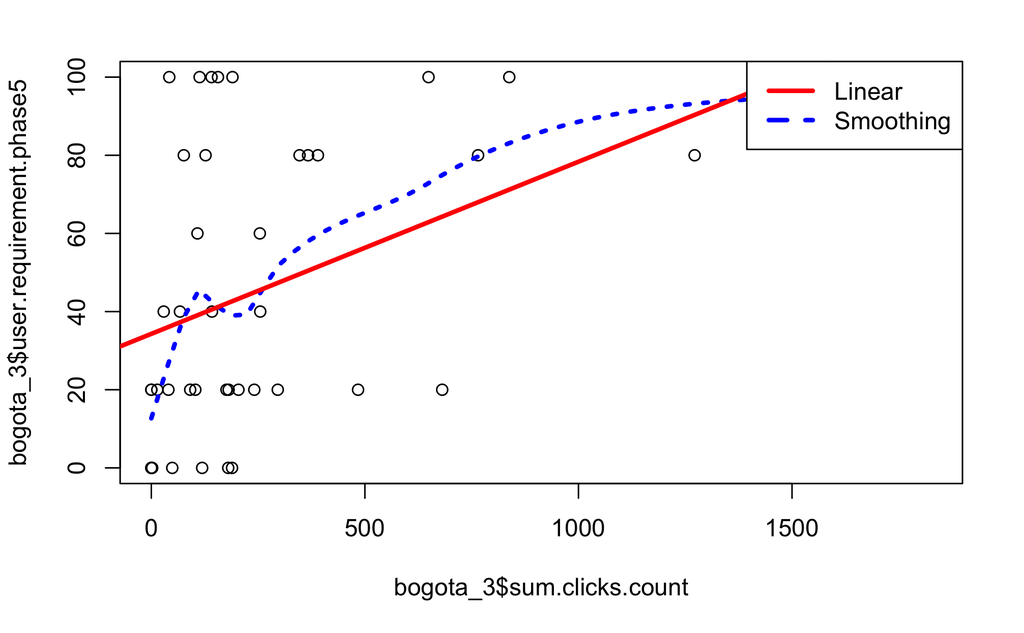

```r
legend('topright', c('Linear','Smoothing'),
lty=c(1,2), lwd=c(3,3), col=c('red','blue'))
```

```r
scatter.smooth(bogota_3$sum.clicks.count, bogota_3$novelty.phase5, lpars = list(col = "blue", lwd = 3, lty = 3))
abline(lm(bogota_3$novelty.phase5~bogota_3$sum.clicks.count), col='red',lwd=3)
```

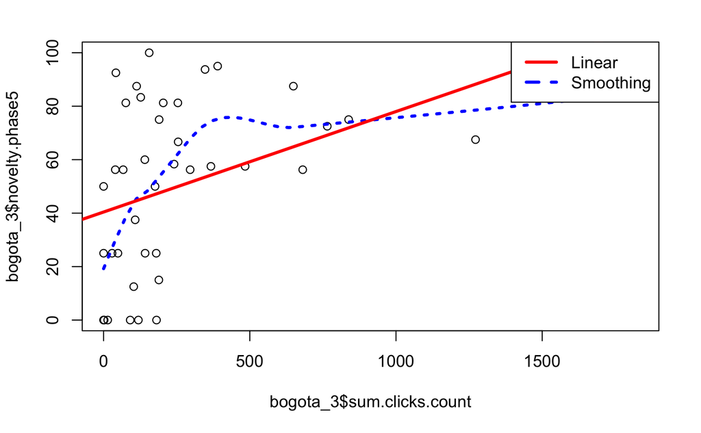

```r
legend('topright', c('Linear','Smoothing'),
lty=c(1,2), lwd=c(3,3), col=c('red','blue'))
```

```r
scatter.smooth(bogota_3$score.clicks.count, bogota_3$novelty.phase5, lpars = list(col = "blue", lwd = 3, lty = 3))
abline(lm(bogota_3$novelty.phase5~bogota_3$score.clicks.count), col='red',lwd=3)
```

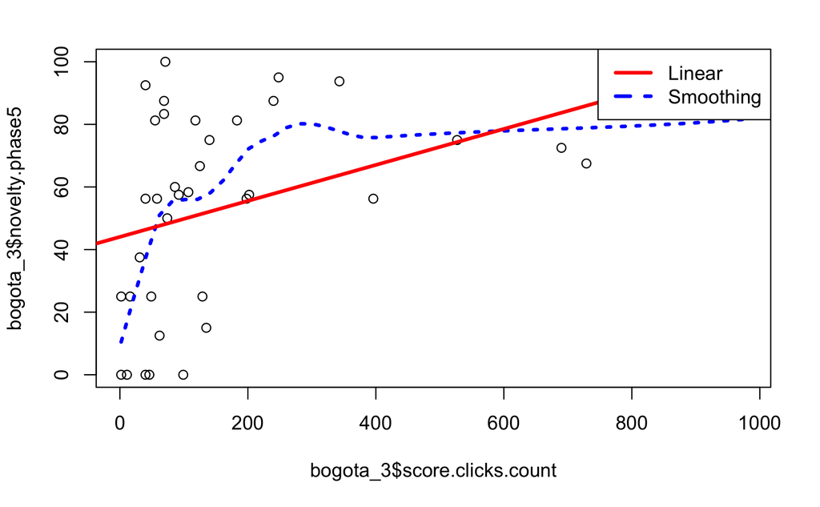

```r
legend('topright', c('Linear','Smoothing'),
lty=c(1,2), lwd=c(3,3), col=c('red','blue'))
```

```r
scatter.smooth(bogota_1$sum.clicks.count, bogota_1$novelty.phase5, lpars = list(col = "blue", lwd = 3, lty = 3))
abline(lm(bogota_1$novelty.phase5~bogota_1$sum.clicks.count), col='red',lwd=3)
```

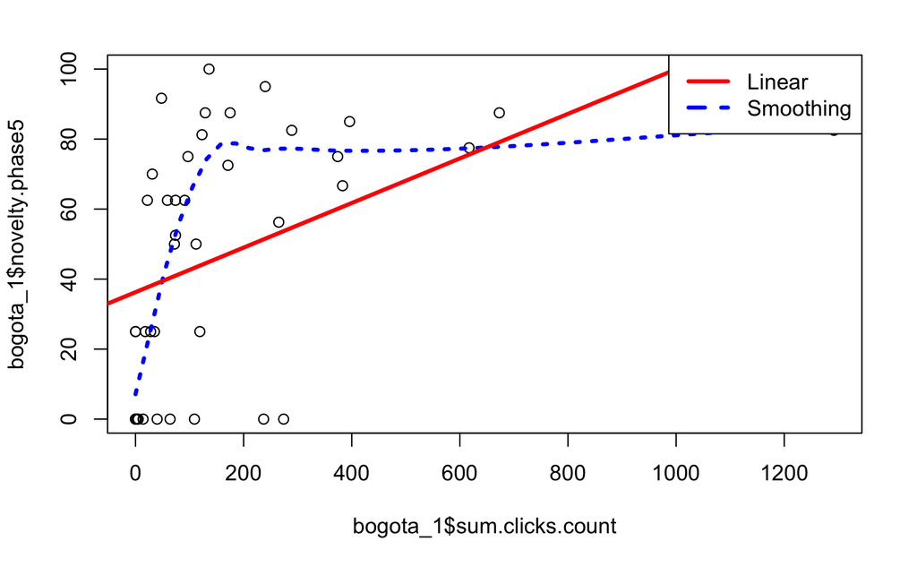

```r
legend('topright', c('Linear','Smoothing'),
lty=c(1,2), lwd=c(3,3), col=c('red','blue'))
```

```r
scatter.smooth(bogota_1$sum.clicks.count, bogota_1$user.requirement.phase5, lpars = list(col = "blue", lwd = 3, lty = 3))
abline(lm(bogota_1$user.requirement.phase5~bogota_1$sum.clicks.count), col='red',lwd=3)
```

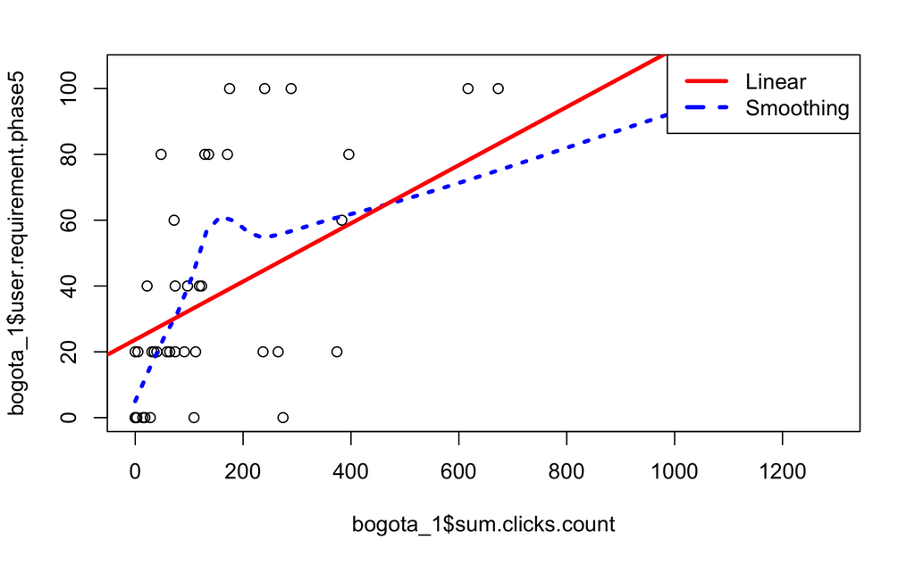

```r
legend('topright', c('Linear','Smoothing'),
lty=c(1,2), lwd=c(3,3), col=c('red','blue'))
```

## Visualization for Significant Scenarios in Overall Groups

```r
scatter.smooth(scores_loc$sum.clicks.count, scores_loc$user.requirement.phase5, lpars = list(col = "blue", lwd = 3, lty = 3))
abline(lm(scores_loc$user.requirement.phase5~scores_loc$sum.clicks.count), col='red',lwd=3)
```

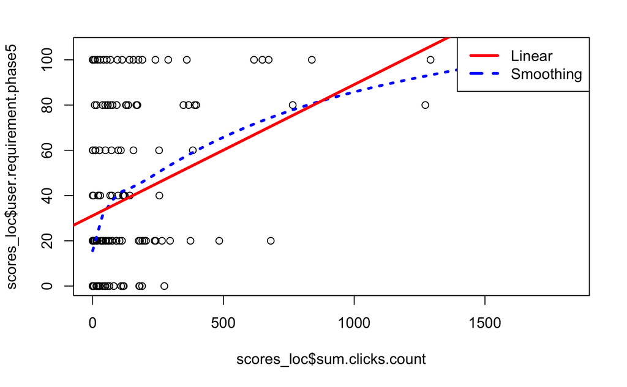

```r
legend('topright', c('Linear','Smoothing'),
lty=c(1,2), lwd=c(3,3), col=c('red','blue'))
```

```r
scatter.smooth(scores_loc$project.clicks.count, scores_loc$user.requirement.phase5, lpars = list(col = "blue", lwd = 3, lty = 3))
abline(lm(scores_loc$user.requirement.phase5~scores_loc$project.clicks.count), col='red',lwd=3)
```

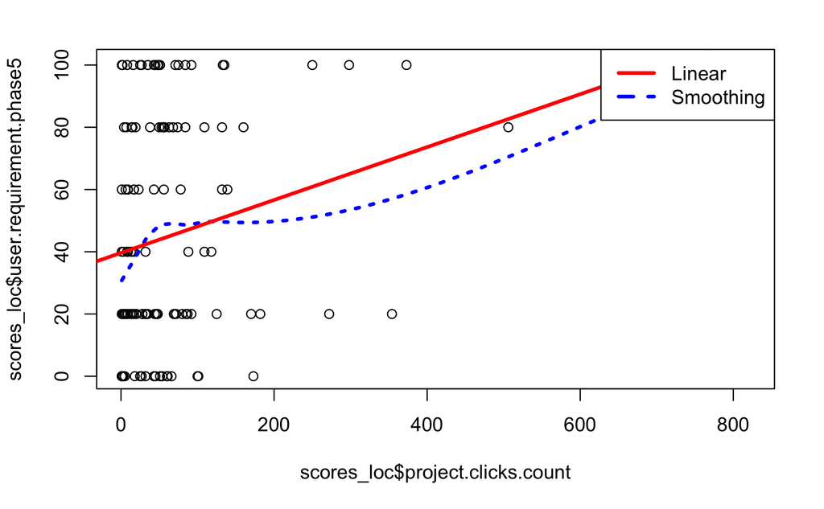

```r
legend('topright', c('Linear','Smoothing'),
lty=c(1,2), lwd=c(3,3), col=c('red','blue'))
```

```r
scatter.smooth(scores_loc$score.clicks.count, scores_loc$user.requirement.phase5, lpars = list(col = "blue", lwd = 3, lty = 3))
abline(lm(scores_loc$user.requirement.phase5~scores_loc$score.clicks.count), col='red',lwd=3)
```

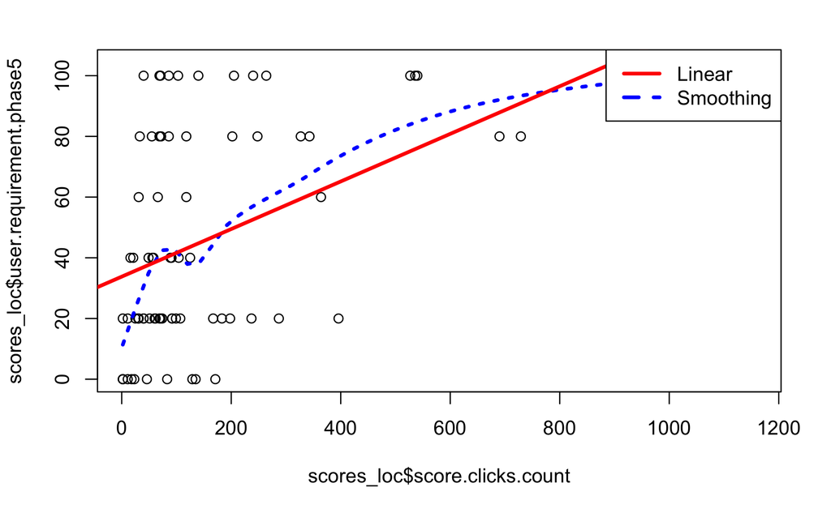

```r
legend('topright', c('Linear','Smoothing'),
lty=c(1,2), lwd=c(3,3), col=c('red','blue'))
```

```r
scatter.smooth(scores_loc$sum.clicks.count, scores_loc$novelty.phase5, lpars = list(col = "blue", lwd = 3, lty = 3))
abline(lm(scores_loc$novelty.phase5~scores_loc$sum.clicks.count), col='red',lwd=3)
```

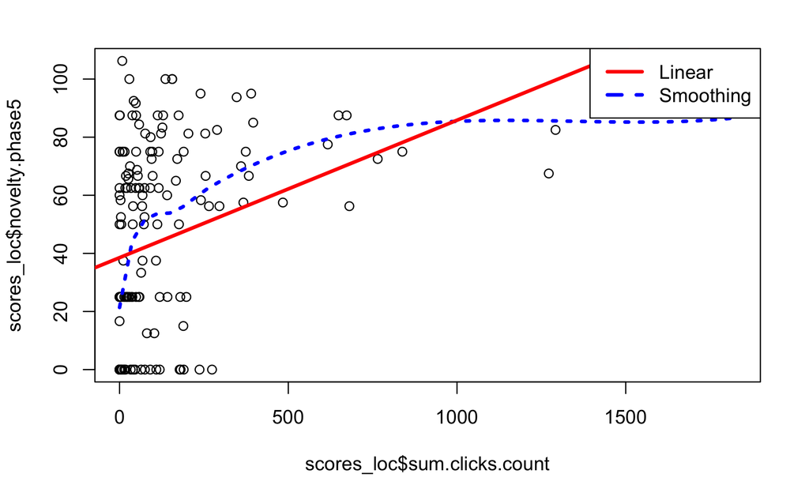

```r
legend('topright', c('Linear','Smoothing'),
lty=c(1,2), lwd=c(3,3), col=c('red','blue'))
```

```r
scatter.smooth(scores_loc$project.clicks.count, scores_loc$novelty.phase5, lpars = list(col = "blue", lwd = 3, lty = 3))
abline(lm(scores_loc$novelty.phase5~scores_loc$project.clicks.count), col='red',lwd=3)
```

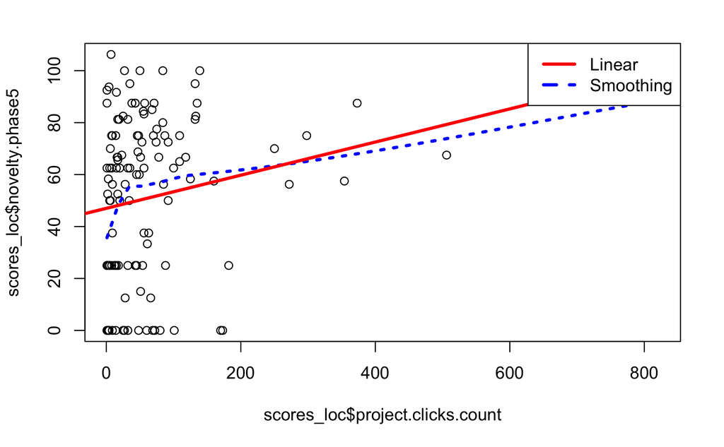

```r
legend('topright', c('Linear','Smoothing'),
lty=c(1,2), lwd=c(3,3), col=c('red','blue'))
```

```r
scatter.smooth(scores_loc$score.clicks.count, scores_loc$novelty.phase5, lpars = list(col = "blue", lwd = 3, lty = 3))
abline(lm(scores_loc$novelty.phase5~scores_loc$score.clicks.count), col='red',lwd=3)
```

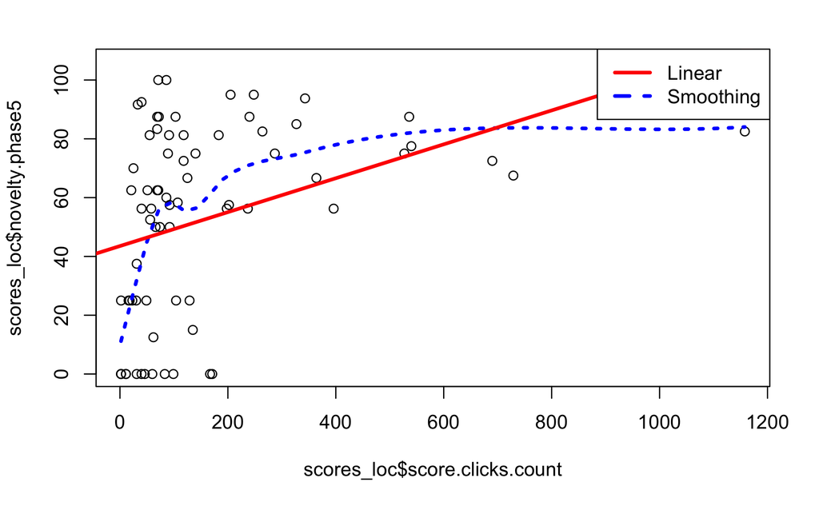

```r
legend('topright', c('Linear','Smoothing'),
lty=c(1,2), lwd=c(3,3), col=c('red','blue'))
```

## Descriptive Statistics for Clicks

```r
library(Rmisc)
library(ggplot2)
summary(bogota_1['score.clicks.count'])
```

```
 score.clicks.count
 Min.   :   2.0
 1st Qu.:  32.5
 Median :  84.5
 Mean   : 157.3
 3rd Qu.: 179.5
 Max.   :1158.0
 NA's   :5
```

```r
library(Rmisc)
library(ggplot2)
summary(bogota_2['project.clicks.count'])
```

```
 project.clicks.count
 Min.   :  1.00
 1st Qu.: 32.00
 Median : 55.00
 Mean   : 68.54
 3rd Qu.: 88.00
 Max.   :250.00
 NA's   :7
```

```r
library(Rmisc)
library(ggplot2)
summary(bogota_3['project.clicks.count'])
```

```
 project.clicks.count
 Min.   :  1.0
 1st Qu.: 43.0
 Median : 60.0
 Mean   :125.2
 3rd Qu.:128.5
 Max.   :821.0
 NA's   :6
```

```r
library(Rmisc)
library(ggplot2)
summary(bogota_3['score.clicks.count'])
```

```
 score.clicks.count
 Min.   :  2.0
 1st Qu.: 49.0
 Median : 92.0
 Mean   :175.7
 3rd Qu.:198.0
 Max.   :978.0
 NA's   :4
```

```r
training<-bogota_3$project.clicks.count
control<-bogota_2$project.clicks.count
mean(training, na.rm=T)-mean(control, na.rm=T)
```

```
[1] 56.68571
```

```r
t.test(training, control, alternative = 'greater')
```

```
    Welch Two Sample t-test

data:  training and control
t = 1.8837, df = 41.652, p-value = 0.0333
alternative hypothesis: true difference in means is greater than 0
95 percent confidence interval:
 6.062433      Inf
sample estimates:
mean of x mean of y
125.22857  68.54286
```

```r
training<-bogota_3$project.clicks.hacker
control<-bogota_2$project.clicks.hacker
mean(training, na.rm=T)-mean(control, na.rm=T)
```

```
[1] 50.92105
```

```r
t.test(training, control, alternative = 'greater')
```

```
    Welch Two Sample t-test

data:  training and control
t = 7.2961, df = 67.517, p-value = 2.146e-10
alternative hypothesis: true difference in means is greater than 0
95 percent confidence interval:
 39.28161      Inf
sample estimates:
mean of x mean of y
115.44737  64.52632
```

```r
training<-bogota_3$unique_apps
control<-bogota_2$unique_apps
mean(training, na.rm=T)-mean(control, na.rm=T)
```

```
[1] 0.9428571
```

```r
t.test(training, control, alternative = 'greater')
```

```
    Welch Two Sample t-test

data:  training and control
t = 0.36059, df = 67.398, p-value = 0.3598
alternative hypothesis: true difference in means is greater than 0
95 percent confidence interval:
 -3.418045       Inf
sample estimates:
mean of x mean of y
 26.25714  25.31429
```